# Statistical Inference Simulation Project

Bindu Shah

## Overview

This is a two-part project.

Part 1: Simulation Exercise This is a theoretical Simulation exercise to investigate the exponential distribution and compare it with the Central Limit Theorem. Both sample mean and sample variance will be comapred to their theoretical counterparts.

Part 2: Basic Inferential Data Analysis This Data Analysis effort will explore the ToothGrowth data set and compare tooth growth by supplements and dosage using confidence intervals/hypotheses testing.

## PART 1: Simulation Exercise

```r
set.seed(7)
lambda<- 0.2
sim_count<-1000
sample_count<-40
```

## Point 1: Caclulate Actual Mean and Theoretical Mean

```r
SimExp<-matrix(rexp(sim_count * sample_count, lambda), sim_count, sample_count)
SimMean<-rowMeans(SimExp)
ActualMean<-mean(SimMean)
TheoreticalMean<-1/lambda
```

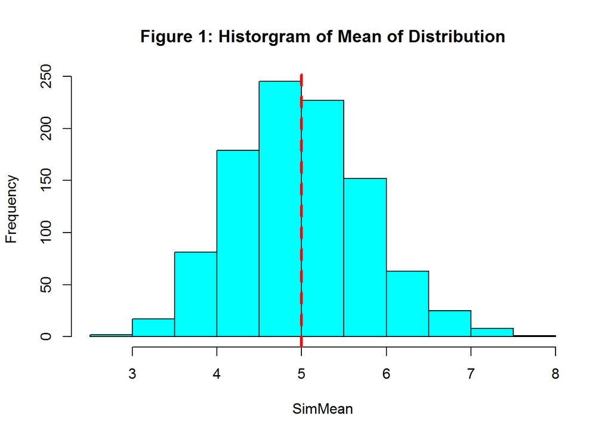

```r
hist(SimMean, col="cyan", main="Figure 1: Historgram of Mean of Distribution")
abline(v=TheoreticalMean, col="red", lwd=3, lty=2)
```

```r
CompareMean<-c(ActualMean, TheoreticalMean)
CompareMean
```

```
## [1] 4.983294 5.000000
```

## Point 2: Compare Actual Variance with Theoretical Variance

```r
ActualVariance<-var(SimMean)

TheoreticalSD<-1/lambda
TheoreticalVariance<-(TheoreticalSD^2)/sample_count
CompareVariance<-c(ActualVariance, TheoreticalVariance)
CompareVariance
```

```
## [1] 0.6061501 0.6250000
```

The Actual Variance is 0.606 which is very close to the Theoretical Variance of 0.625

## Point 3: Simlated Distribution is normal conforming to CLT

Per the Central Limit Theorem, given a sufficiently large sample size from a population with a finite level of variance, the mean of all samples from the same population will be approximately equal to the mean of the population.

Collection of 1000 random uniforms:

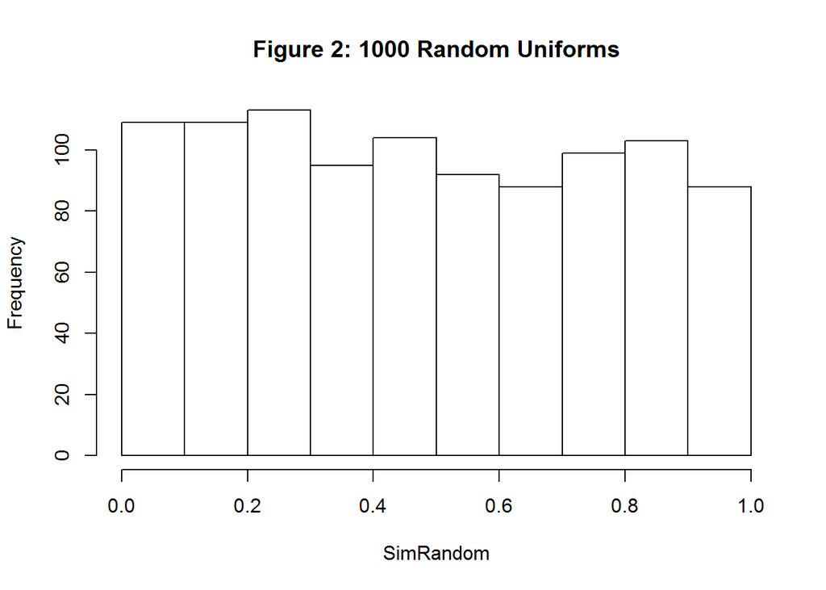

```r
SimRandom<- runif(1000)
hist(SimRandom, main="Figure 2: 1000 Random Uniforms")
```

```r
mean(SimRandom)
```

```
## [1] 0.4825033
```

Distribution of 1000 average of 40 random uniforms

```r
mns = NULL
for (i in 1 : 1000) mns = c(mns, mean(runif(40)))
mean(mns)
```

```
## [1] 0.4974966
```

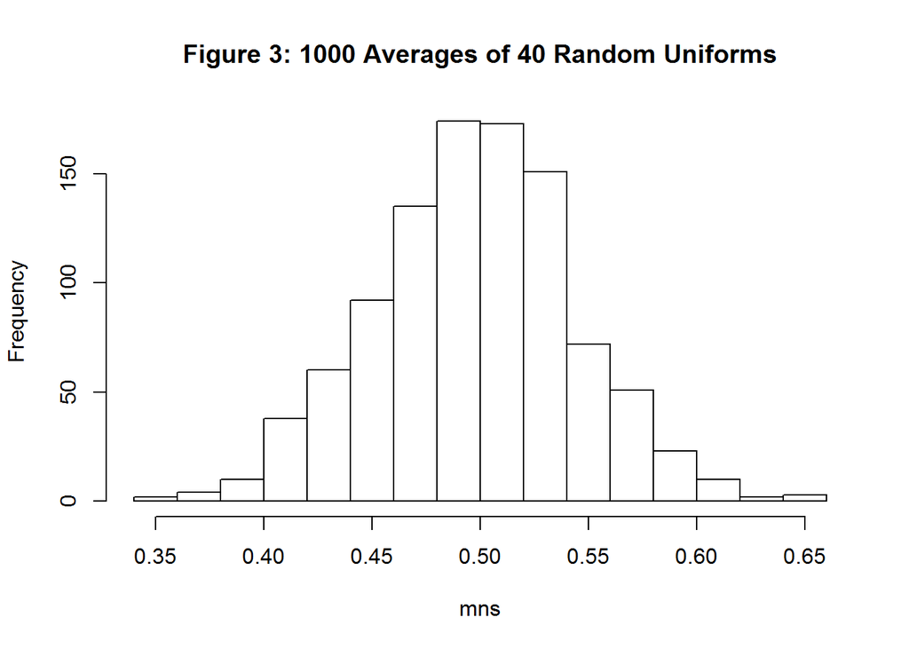

```r
hist(mns, main="Figure 3: 1000 Averages of 40 Random Uniforms")
```

## PART 2: Analysis of the ToothGrowth Data set

The ToothGrowth data set explores The Effect of Vitamin C on Tooth Growth in Guinea Pigs

The response is the length of odontoblasts (cells responsible for tooth growth) in 60 guinea pigs. Each animal received one of three dose levels of vitamin C (0.5, 1, and 2 mg/day) by one of two delivery methods, (orange juice or ascorbic acid (a form of vitamin C and coded as VC).

A data frame with 60 observations on 3 variables.

- len numeric Tooth length
- supp factor Supplement type (VC or OJ).
- dose numeric Dose in milligrams/day

## Load ToothGrowth data

```r
data(ToothGrowth)
str(ToothGrowth)
```

```
## 'data.frame':    60 obs. of  3 variables:
##  $ len : num  4.2 11.5 7.3 5.8 6.4 10 11.2 11.2 5.2 7 ...
##  $ supp: Factor w/ 2 levels "OJ","VC": 2 2 2 2 2 2 2 2 2 2 ...
##  $ dose: num  0.5 0.5 0.5 0.5 0.5 0.5 0.5 0.5 0.5 0.5 ...
```

```r
head(ToothGrowth)
```

```
##    len supp dose
## 1  4.2   VC  0.5
## 2 11.5   VC  0.5
## 3  7.3   VC  0.5
## 4  5.8   VC  0.5
## 5  6.4   VC  0.5
## 6 10.0   VC  0.5
```

## summary of ToothGrowth Data

```r
summary(ToothGrowth)
```

```
##       len        supp         dose
##  Min.   : 4.20   OJ:30   Min.   :0.500
##  1st Qu.:13.07   VC:30   1st Qu.:0.500
##  Median :19.25           Median :1.000
##  Mean   :18.81           Mean   :1.167
##  3rd Qu.:25.27           3rd Qu.:2.000
##  Max.   :33.90           Max.   :2.000
```

## Exploratory Analysis

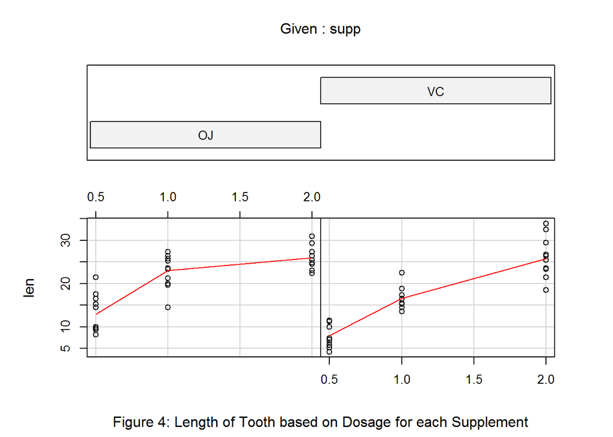

```r
require(graphics)
coplot(len ~ dose | supp, data = ToothGrowth, panel = panel.smooth,
  xlab = "Figure 4: Length of Tooth based on Dosage for each Supplement")
```